# ASSIGNMENT 5: FMST

### Ridge Regressor 3rd Degree

```
Ridge Train: 0.9159302994501114
Ridge Test: 0.8870380615961561
[-188.60380747  -21.70734416    1.35447469   26.16767451  174.6768885 ]
```

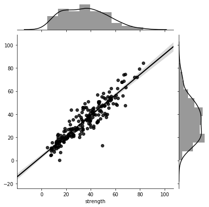

```python
x_train, x_test, y_train, y_test = train_test_split(x, y, test_size = 0.2, random_state = 1)
pipe_ridge = Pipeline([("Poly",PolynomialFeatures(degree = 3, interaction_only = False)),("regressor", Ridge(alpha = 0.01))])
pipe_ridge.fit(x_train, y_train)
y_pred_ridge = pipe_ridge.predict(x_test)
print("Ridge Train:", pipe_ridge.score(x_train, y_train))
print("Ridge Test:", pipe_ridge.score(x_test, y_test))
ridge_full_3d = pipe_ridge.score(x_test, y_test)
print(np.percentile(pipe_ridge.named_steps["regressor"].coef_,[0,25,50,75,100]))
sns.jointplot(x = y_test, y = y_pred, kind = "reg", color = "k")
```

### Ridge performance is also quite good on the 3rd degree polynomial. This can be an algorithm to consider

### Lasso Regression 3rd Degree

```
Lasso Train: 0.9109637951241768
Lasso Test: 0.8909734699278685
[-336.40473765   -1.2099959    -0.            3.29269155  195.70459368]
```

[figure not shown]

```python
x_train, x_test, y_train, y_test = train_test_split(x, y, test_size = 0.2, random_state = 1)
pipe_lasso = Pipeline([("Poly",PolynomialFeatures(degree = 3, interaction_only = False)),("regressor", Lasso(alpha = 0.001, max_iter=100000, tol = 0.001, precompute=True, warm_start=True))])
pipe_lasso.fit(x_train, y_train)
y_pred_lasso = pipe_lasso.predict(x_test)
print("Lasso Train:", pipe_lasso.score(x_train, y_train))
print("Lasso Test:", pipe_lasso.score(x_test, y_test))
lasso_full_3d = pipe_lasso.score(x_test, y_test)
print(np.percentile(pipe_lasso.named_steps["regressor"].coef_,[0,25,50,75,100]))
sns.jointplot(x = y_test, y = y_pred, kind = "reg", color = "k")
```

### Lasso is very close to ridge in performance. What we do see is the continuance of large coefficients though

### Comparing the performance of the algorithms

```
<BarContainer object of 10 artists>
```

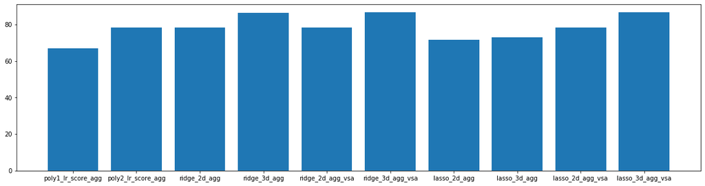

```python
plt.figure(figsize = (20,5))
plt.bar (["poly1_lr_score_agg","poly2_lr_score_agg","ridge_2d_agg","ridge_3d_agg","ridge_2d_agg_vsa","ridge_3d_agg_vsa","lasso_2d_agg","lasso_3d_agg","lasso_2d_agg_vsa","lasso_3d_agg_vsa"], [poly1_lr_score_agg*100,poly2_lr_score_agg*100,ridge_2d_agg*100,ridge_3d_agg*100,ridge_2d_agg_vsa*100,ridge_3d_agg_vsa*100,lasso_2d_agg*100,lasso_3d_agg*100,lasso_2d_agg_vsa*100,lasso_3d_agg_vsa*100])
```

```
<BarContainer object of 10 artists>
```

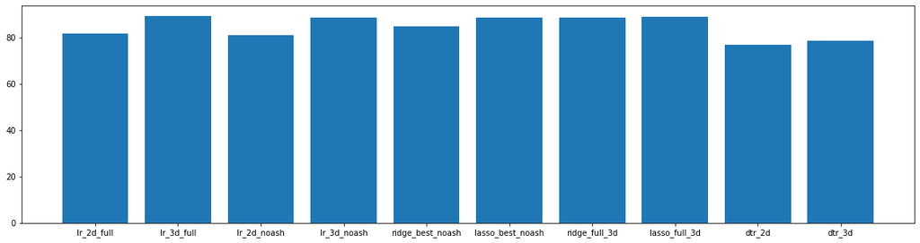

```python
plt.figure(figsize = (20,5))
plt.bar (["lr_2d_full", "lr_3d_full", "lr_2d_noash", "lr_3d_noash", "ridge_best_noash","lasso_best_noash","ridge_full_3d","lasso_full_3d", "dtr_2d", "dtr_3d"], [ lr_2d_full*100, lr_3d_full*100, lr_2d_noash*100, lr_3d_noash*100, ridge_best_noash*100,lasso_best_noash*100,ridge_full_3d*100,lasso_full_3d*100, dtr_2d*100, dtr_3d*100])
```

## Q9. and Q10

## Techniques employed to squeeze that extra performance out of the model without making it overfit or underfit

## Model performance range at 95% confidence level

## Ans9 and Ans10 Done Together

### We will attempt a randomizedsearchCV to get the right parameters on the aggregated data for 3D Ridge and Lasso. That seems to be our best bet of improving performance

### Create Train, Test and Validation sets

```python
x = scaled_concrete_agg
y = concrete["strength"]
x_train_val, x_test, y_train_val, y_test = train_test_split(x, y, test_size = 0.2, random_state = 1)
x_train, x_val, y_train, y_val = train_test_split(x_train_val, y_train_val, test_size = 0.2, random_state = 1)
poly = PolynomialFeatures(degree = 3, interaction_only = False)
x_poly_train_val = poly.fit_transform(x_train_val)
x_poly_train = poly.transform(x_train)
x_test = poly.transform(x_test)
x_poly_val = poly.transform(x_val)
```

### Ridge Regression on 3rd degree polynomial

### Create parameter grid

```python
param_grid = {"alpha":[0.001,0.01,0.1,0.2,0.3,0.4,0.5],
             "fit_intercept":[True, False],
             "normalize":[True, False],
             "max_iter":[100000],
             "tol":[0.0001,0.0003,0.0005,0.0007,0.0009,0.0011,0.0013,0.0015,0.0017,0.0019,0.0021],
             "solver":["auto"]}

#"alpha":[0.0000005,0.0000007,0.0000009,0.000001,0.000003,0.000005,0.000007, 0.000009]
```

### Perform Randomized search on data and find best parameters

```python
ridge_search = RandomizedSearchCV(Ridge(alpha=0.00001), param_distributions = param_grid, cv = 3, verbose=True)
ridge_search.fit(x_poly_train, y_train)
y_pred_ridge = ridge_search.predict(x_poly_val)
print("Best Params:", ridge_search.best_params_)
print("Accuracy is:" , round(ridge_search.score(x_poly_val,y_val) * 100,2))
```

```
Fitting 3 folds for each of 10 candidates, totalling 30 fits
Best Params: {'tol': 0.0003, 'solver': 'auto', 'normalize': True, 'max_iter': 100000, 'fit_intercept': False, 'alpha': 0.01}
Accuracy is: 86.7
```

```
[Parallel(n_jobs=1)]: Using backend SequentialBackend with 1 concurrent workers.
[Parallel(n_jobs=1)]: Done  30 out of  30 | elapsed:    0.0s finished
```

```
Range of Results [77.56 81.47 83.2  83.34 84.59 85.2  86.14 86.25 88.99 90.33]
Results Accuracy: 84.71 %
Results Std: 3.47 %
95% confidence range 77.77 - 91.64
```

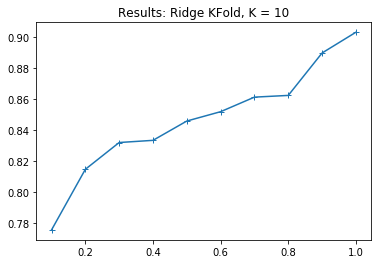

```python
num_fold = 10
kfold = KFold(n_splits=num_fold, shuffle = True, random_state = 100)

ridge_kfold = Ridge(tol = 0.0003, solver = 'auto', normalize = False, max_iter = 100000, fit_intercept= False, alpha = 0.01)
ridge_kfold_result = cross_val_score(ridge_kfold, x_poly_train_val, y_train_val, cv = kfold)
ridge_kfold_result = np.sort(ridge_kfold_result)
print("Range of Results", np.round(ridge_kfold_result*100,2))
perc_accuracy = ridge_kfold_result.mean()*100
std_dev = ridge_kfold_result.std()*100
print ("Results Accuracy:", round(perc_accuracy,2),"%")
print ("Results Std:", round(std_dev,2), "%")
min_range = round((perc_accuracy - 2*std_dev),2)
max_range = round((perc_accuracy + 2*std_dev),2)
if min_range < 0:
    min_range = 0
if max_range > 100:
    max_range = 100
print ("95% confidence range", min_range, "-", max_range)
plt.plot((np.array(range(1, 11))/10),ridge_kfold_result, marker = "+")
plt.title("Results: Ridge KFold, K = 10")
```

```python
ridge_kfold.fit(x_poly_train_val, y_train_val)
print("Accuracy is", ridge_kfold.score(x_test, y_test)*100)
```

```
Accuracy is 86.35332592289879
```

### The ridge regression performance range at 95% confidence is 77.77 - 91.64%

### Lasso Regression on 3rd Degree Polynomial

### Create param grid

```python
param_grid = {"alpha":[0.0001,0.0003,0.0005,0.0007,0.0009,0.001,0.01,0.1,0.2,0.3,0.4,0.5],
             "fit_intercept":[True, False],
             "normalize":[True, False],
             "max_iter":[100000],
             "tol":[0.0001,0.0003,0.0005,0.0007,0.0009,0.0011,0.0013,0.0015,0.0017,0.0019,0.0021]}

#"alpha":[0.0000005,0.0000007,0.0000009,0.000001,0.000003,0.000005,0.000007, 0.000009]
```

### Perform RandomizedSearchCV on training data and find best parameters

```python
lasso_search = RandomizedSearchCV(Lasso(alpha=0.00001), param_distributions = param_grid, cv = 3, verbose=True)
lasso_search.fit(x_poly_train, y_train)
y_pred_lasso = lasso_search.predict(x_poly_val)
print("Best Params:", lasso_search.best_params_)
print("Accuracy is:" , round(lasso_search.score(x_poly_val,y_val) * 100,2))
```

```
Fitting 3 folds for each of 10 candidates, totalling 30 fits
```

```
[Parallel(n_jobs=1)]: Using backend SequentialBackend with 1 concurrent workers.
[Parallel(n_jobs=1)]: Done  30 out of  30 | elapsed:   39.9s finished
```

```
Best Params: {'tol': 0.0011, 'normalize': False, 'max_iter': 100000, 'fit_intercept': False, 'alpha': 0.001}
Accuracy is: 86.69
```

```
Range of Results [77.84 81.17 82.66 83.28 84.07 85.19 85.65 86.43 88.83 90.35]
Results Accuracy: 84.55 %
Results Std: 3.45 %
95% confidence range 77.65 - 91.45
```

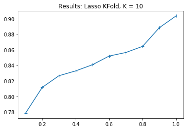

```python
num_fold = 10
kfold = KFold(n_splits=num_fold, shuffle = True, random_state = 100)

lasso_kfold = Lasso(tol = 0.0011, normalize = True, max_iter = 100000, fit_intercept= False, alpha = 0.001)
lasso_kfold_result = cross_val_score(lasso_kfold, x_poly_train_val, y_train_val, cv = kfold)
lasso_kfold_result = np.sort(lasso_kfold_result)
print("Range of Results", np.round(lasso_kfold_result*100,2))
perc_accuracy = lasso_kfold_result.mean()*100
std_dev = lasso_kfold_result.std()*100
print ("Results Accuracy:", round(perc_accuracy,2),"%")
print ("Results Std:", round(std_dev,2), "%")
min_range = round((perc_accuracy - 2*std_dev),2)
max_range = round((perc_accuracy + 2*std_dev),2)
if min_range < 0:
    min_range = 0
if max_range > 100:
    max_range = 100
print ("95% confidence range", min_range, "-", max_range)
plt.plot((np.array(range(1, 11))/10),lasso_kfold_result, marker = "+")
plt.title("Results: Lasso KFold, K = 10")
```

```python
lasso_kfold.fit(x_poly_train_val, y_train_val)
print("Accuracy is", lasso_kfold.score(x_test, y_test)*100)
```

```
Accuracy is 86.36294338165924
```

### The Lasso regression performance range at 95% confidence is 77.65 - 91.45%

### Linear regression, 3rd degree polynomial

### Create model and estimate performance range at 95% confidence

```
Range of Results [77.05 79.88 82.02 82.95 85.17 86.04 86.08 86.43 87.4  87.58]
Results Accuracy: 84.06 %
Results Std: 3.32 %
95% confidence range 77.41 - 90.71
```

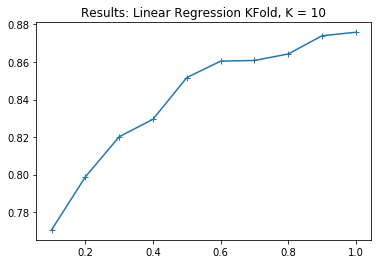

```python
num_fold = 10
kfold = KFold(n_splits=num_fold, shuffle = True, random_state = 100)

linear_regression = LinearRegression(fit_intercept=False)
lr_kfold_result = cross_val_score(linear_regression, x_poly_train_val, y_train_val, cv = kfold)
lr_kfold_result = np.sort(lr_kfold_result)
print("Range of Results", np.round(lr_kfold_result*100,2))
perc_accuracy = lr_kfold_result.mean()*100
std_dev = lr_kfold_result.std()*100
print ("Results Accuracy:", round(perc_accuracy,2),"%")
print ("Results Std:", round(std_dev,2), "%")
min_range = round((perc_accuracy - 2*std_dev),2)
max_range = round((perc_accuracy + 2*std_dev),2)
if min_range < 0:
    min_range = 0
if max_range > 100:
    max_range = 100
print ("95% confidence range", min_range, "-", max_range)
plt.plot((np.array(range(1, 11))/10),lr_kfold_result, marker = "+")
plt.title("Results: Linear Regression KFold, K = 10")
```

```python
linear_regression.fit(x_poly_train_val, y_train_val)
print("Accuracy is", linear_regression.score(x_test, y_test)*100)
```

```
Accuracy is 86.19891879941875
```

### The linear regression performance range for 3rd degree polynomial is 77.41 - 90.71%.

### Linear regression, 2rd degree polynomial

```python
x = scaled_concrete_agg
y = concrete["strength"]
x_train_val, x_test, y_train_val, y_test = train_test_split(x, y, test_size = 0.2, random_state = 1)
x_train, x_val, y_train, y_val = train_test_split(x_train_val, y_train_val, test_size = 0.2, random_state = 1)
poly = PolynomialFeatures(degree = 2, interaction_only = False)
x_poly_train_val = poly.fit_transform(x_train_val)
x_poly_train = poly.transform(x_train)
x_test = poly.transform(x_test)
x_poly_val = poly.transform(x_val)
```

### Create model based and estimate performance range at 95% confidence

```
Range of Results [38.88 69.57 69.83 74.52 75.11 77.15 78.5  79.31 82.07 82.19]
Results Accuracy: 72.71 %
Results Std: 12.02 %
95% confidence range 48.67 - 96.76
```

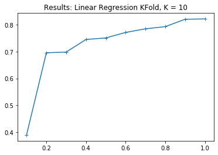

```python
num_fold = 10
kfold = KFold(n_splits=num_fold, shuffle = True, random_state = 100)
linear_regression = LinearRegression()
lr_kfold_result = cross_val_score(linear_regression, x_poly_train_val, y_train_val, cv = kfold)
lr_kfold_result = np.sort(lr_kfold_result)
print("Range of Results", np.round(lr_kfold_result*100,2))
perc_accuracy = lr_kfold_result.mean()*100
std_dev = lr_kfold_result.std()*100
print ("Results Accuracy:", round(perc_accuracy,2),"%")
print ("Results Std:", round(std_dev,2), "%")
min_range = round((perc_accuracy - 2*std_dev),2)
max_range = round((perc_accuracy + 2*std_dev),2)
if min_range < 0:
    min_range = 0
if max_range > 100:
    max_range = 100
print ("95% confidence range", min_range, "-", max_range)
plt.plot((np.array(range(1, 11))/10),lr_kfold_result, marker = "+")
plt.title("Results: Linear Regression KFold, K = 10")
```

```python
linear_regression.fit(x_poly_train_val, y_train_val)
print("Accuracy is", linear_regression.score(x_test, y_test)*100)
```

```
Accuracy is 78.42828720499742
```

### The Linear regression performance range for 2nd degree polynomial at 95% confidence is 48.67 - 96.76%.

### Decision Tree on 3rd Degree polynomial

```python
x = scaled_concrete_agg
y = concrete["strength"]
x_train_val, x_test, y_train_val, y_test = train_test_split(x, y, test_size = 0.2, random_state = 1)
x_train, x_val, y_train, y_val = train_test_split(x_train_val, y_train_val, test_size = 0.2, random_state = 1)
poly = PolynomialFeatures(degree = 3, interaction_only = False)
x_poly_train_val = poly.fit_transform(x_train_val)
x_poly_train = poly.transform(x_train)
x_test = poly.transform(x_test)
x_poly_val = poly.transform(x_val)
```

```python
param_grid = {"max_depth":[3,4,5,6,7,8,9,10,11,12,13,14],
             "max_features":[1,2,3,4,5,6,7,8,9],
              "min_samples_split": [2,3,4,5,6],
             "min_samples_leaf": [1,2,3,4,5,6]}

#"alpha":[0.0000005,0.0000007,0.0000009,0.000001,0.000003,0.000005,0.000007, 0.000009]
```

```python
dtr_search = RandomizedSearchCV(DecisionTreeRegressor(max_depth=3), param_distributions = param_grid, cv = 3, verbose=True)
dtr_search.fit(x_poly_train, y_train)
y_pred_dtr = dtr_search.predict(x_poly_val)
print("Best Params:", dtr_search.best_params_)
print("Accuracy is:" , round(dtr_search.score(x_poly_val,y_val) * 100,2))
```

```
Fitting 3 folds for each of 10 candidates, totalling 30 fits
Best Params: {'min_samples_split': 4, 'min_samples_leaf': 6, 'max_features': 9, 'max_depth': 10}
Accuracy is: 83.2
```

```
[Parallel(n_jobs=1)]: Using backend SequentialBackend with 1 concurrent workers.
[Parallel(n_jobs=1)]: Done  30 out of  30 | elapsed:    0.0s finished
```

### Create model based on best params and estimate performance range at 95% confidence

```
Range of Results [69.48 72.21 75.6  78.65 79.83 82.73 83.59 83.68 83.84 84.73]
Results Accuracy: 79.43 %
Results Std: 5.1 %
95% confidence range 69.22 - 89.64
```

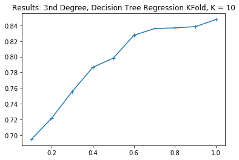

```python
num_fold = 10
kfold = KFold(n_splits=num_fold, shuffle = True, random_state = 100)
dtr_optimal = DecisionTreeRegressor(min_samples_split = 4, min_samples_leaf = 6, max_features = 9, max_depth = 10)
dtr_kfold_result_poly3 = cross_val_score(dtr_optimal, x_poly_train_val, y_train_val, cv = kfold)
dtr_kfold_result_poly3 = np.sort(dtr_kfold_result_poly3)
print("Range of Results", np.round(dtr_kfold_result_poly3*100,2))
perc_accuracy = dtr_kfold_result_poly3.mean()*100
std_dev = dtr_kfold_result_poly3.std()*100
print ("Results Accuracy:", round(perc_accuracy,2),"%")
print ("Results Std:", round(std_dev,2), "%")
min_range = round((perc_accuracy - 2*std_dev),2)
max_range = round((perc_accuracy + 2*std_dev),2)
if min_range < 0:
    min_range = 0
if max_range > 100:
    max_range = 100
print ("95% confidence range", min_range, "-", max_range)
plt.plot((np.array(range(1, 11))/10),dtr_kfold_result_poly3, marker = "+")
plt.title("Results: 3nd Degree, Decision Tree Regression KFold, K = 10")
```

```python
dtr_optimal.fit(x_poly_train_val, y_train_val)
print("Accuracy is", dtr_optimal.score(x_test, y_test)*100)
```

```
Accuracy is 82.28557796148358
```

### The Decision Tree regression performance range for 3rd degree polynomial at 95% confidence is 69.22 - 89.64%

### Decision Tree 2nd Degree Polynomial

### Creating training, validation and test data sets

```python
x = scaled_concrete_agg
y = concrete["strength"]
x_train_val, x_test, y_train_val, y_test = train_test_split(x, y, test_size = 0.2, random_state = 1)
x_train, x_val, y_train, y_val = train_test_split(x_train_val, y_train_val, test_size = 0.2, random_state = 1)
poly = PolynomialFeatures(degree = 2, interaction_only = False)
x_poly_train_val = poly.fit_transform(x_train_val)
x_poly_train = poly.transform(x_train)
x_test = poly.transform(x_test)
x_poly_val = poly.transform(x_val)
```

### Performing randomizedsearchCV to discover best params

```python
dtr_search = RandomizedSearchCV(DecisionTreeRegressor(max_depth=3), param_distributions = param_grid, cv = 3, verbose=True)
dtr_search.fit(x_poly_train, y_train)
y_pred_dtr = dtr_search.predict(x_poly_val)
print("Best Params:", dtr_search.best_params_)
print("Accuracy is:" , round(dtr_search.score(x_poly_val,y_val) * 100,2))
```

```
Fitting 3 folds for each of 10 candidates, totalling 30 fits
Best Params: {'min_samples_split': 3, 'min_samples_leaf': 1, 'max_features': 9, 'max_depth': 8}
Accuracy is: 77.35
```

```
[Parallel(n_jobs=1)]: Using backend SequentialBackend with 1 concurrent workers.
[Parallel(n_jobs=1)]: Done  30 out of  30 | elapsed:    0.0s finished
```

### Create model based on best params and estimate performance range at 95% confidence

```
Range of Results [70.82 76.45 80.02 80.43 82.45 82.49 82.96 83.25 84.21 85.27]
Results Accuracy: 80.84 %
Results Std: 4.09 %
95% confidence range 72.66 - 89.01
```

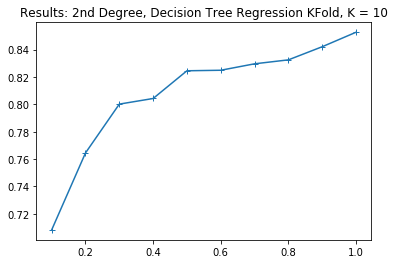

```python
num_fold = 10
kfold = KFold(n_splits=num_fold, shuffle = True, random_state = 100)
dtr_optimal = DecisionTreeRegressor(min_samples_split = 3, min_samples_leaf = 1, max_features = 9, max_depth = 8)
dtr_kfold_result_poly2 = cross_val_score(dtr_optimal, x_poly_train_val, y_train_val, cv = kfold)
dtr_kfold_result_poly2 = np.sort(dtr_kfold_result_poly2)
print("Range of Results", np.round(dtr_kfold_result_poly2*100,2))
perc_accuracy = dtr_kfold_result_poly2.mean()*100
std_dev = dtr_kfold_result_poly2.std()*100
print ("Results Accuracy:", round(perc_accuracy,2),"%")
print ("Results Std:", round(std_dev,2), "%")
min_range = round((perc_accuracy - 2*std_dev),2)
max_range = round((perc_accuracy + 2*std_dev),2)
if min_range < 0:
    min_range = 0
if max_range > 100:
    max_range = 100
print ("95% confidence range", min_range, "-", max_range)
plt.plot((np.array(range(1, 11))/10),dtr_kfold_result_poly2, marker = "+")
plt.title("Results: 2nd Degree, Decision Tree Regression KFold, K = 10")
```

```python
dtr_optimal.fit(x_poly_train_val, y_train_val)
print("Accuracy is", dtr_optimal.score(x_test, y_test)*100)
```

```
Accuracy is 78.0675833472003
```

### The Decision Tree regression performance range for 2nd degree polynomial at 95% confidence is 72.66 - 89.01%.

### Create param grid

```python
param_grid = {"C":[0.005, 0.01, 0.05, 0.1, 0.5, 1, 5, 10, 50, 100],
             "tol":[0.001, 0.0005,0.001,0.005,0.01],
              "kernel":["poly"],
             "degree":[2, 3, 4, 5, 6]}

#"alpha":[0.0000005,0.0000007,0.0000009,0.000001,0.000003,0.000005,0.000007, 0.000009]
```

### Creating training, validation and test data sets

```python
x = scaled_concrete_agg
y = concrete["strength"]
x_train_val, x_test, y_train_val, y_test = train_test_split(x, y, test_size = 0.2, random_state = 1)
x_train, x_val, y_train, y_val = train_test_split(x_train_val, y_train_val, test_size = 0.2, random_state = 1)
```

### Searching for best parameters

```python
svr_search = RandomizedSearchCV(SVR(C=1), param_distributions = param_grid, cv = 3, verbose=True)
svr_search.fit(x_poly_train, y_train)
y_pred_svr = svr_search.predict(x_poly_val)
print("Best Params:", svr_search.best_params_)
print("Accuracy is:" , round(svr_search.score(x_poly_val,y_val) * 100,2))
```

```
Fitting 3 folds for each of 10 candidates, totalling 30 fits
```

```
[Parallel(n_jobs=1)]: Using backend SequentialBackend with 1 concurrent workers.
```

```
Best Params: {'tol': 0.001, 'kernel': 'poly', 'degree': 3, 'C': 50}
Accuracy is: 86.74
```

```
[Parallel(n_jobs=1)]: Done  30 out of  30 | elapsed:    1.8s finished
```

### KFold Validation and determination of performance range at 95% confidence

```
Range of Results [76.83 79.64 84.05 84.26 84.37 84.67 84.75 88.54 88.69 89.63]
Results Accuracy: 84.54 %
Results Std: 3.78 %
95% confidence range 76.98 - 92.1
```

[figure not shown]

```python
num_fold = 10
kfold = KFold(n_splits=num_fold, shuffle = True, random_state = 100)
svr_optimal = SVR(C = 50, tol = 0.001, degree = 3, kernel = "poly")
svr_kfold_result = cross_val_score(svr_optimal, x_poly_train_val, y_train_val, cv = kfold)
svr_kfold_result = np.sort(svr_kfold_result)
print("Range of Results", np.round(svr_kfold_result*100,2))
perc_accuracy = svr_kfold_result.mean()*100
std_dev = svr_kfold_result.std()*100
print ("Results Accuracy:", round(perc_accuracy,2),"%")
print ("Results Std:", round(std_dev,2), "%")
min_range = round((perc_accuracy - 2*std_dev),2)
max_range = round((perc_accuracy + 2*std_dev),2)
if min_range < 0:
    min_range = 0
if max_range > 100:
    max_range = 100
print ("95% confidence range", min_range, "-", max_range)
plt.plot((np.array(range(1, 11))/10),svr_kfold_result, marker = "+")
plt.title("Results: 2nd Degree, Decision Tree Regression KFold, K = 10")
```

### The SVR model at degree 3 performs between 76.98 - 92.1% at a confidence level of 95%

## Q10 Model performance range at 95% confidence level

## Ans10. We have already done the performance estimation at 95% confidence. We will now showcase it below

### Let us Compare the models

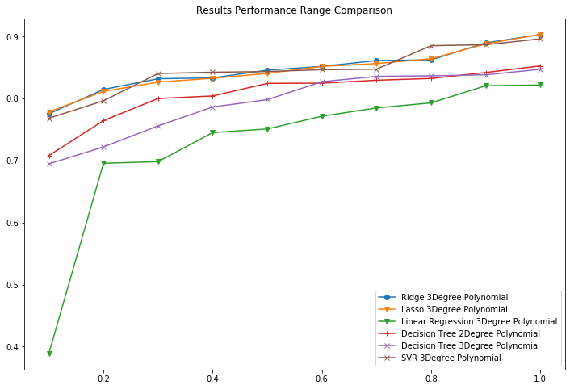

```python
plt.figure (figsize = (12,8))
plt.plot((np.array(range(1, 11))/10),ridge_kfold_result, label = "Ridge 3Degree Polynomial", marker = "o")
plt.plot((np.array(range(1, 11))/10),lasso_kfold_result, label = "Lasso 3Degree Polynomial", marker = "v")
plt.plot((np.array(range(1, 11))/10),lr_kfold_result, label = "Linear Regression 3Degree Polynomial", marker = "v")
plt.plot((np.array(range(1, 11))/10),dtr_kfold_result_poly2, label = "Decision Tree 2Degree Polynomial", marker = "+")
plt.plot((np.array(range(1, 11))/10),dtr_kfold_result_poly3, label = "Decision Tree 3Degree Polynomial", marker = "x")
plt.plot((np.array(range(1, 11))/10),svr_kfold_result, label = "SVR 3Degree Polynomial", marker = "x")

plt.title("Results Performance Range Comparison")
plt.legend(loc = "best")
```

### Model Accuracy mean

[output not shown]

```
<BarContainer object of 6 artists>
```

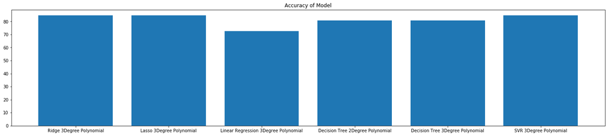

```python
print ("Ridge 3Degree Polynomial", ridge_kfold_result.mean()*100)
print ("SVR 3Degree Polynomial", svr_kfold_result.mean()*100)
print ("Lasso 3Degree Polynomial", lasso_kfold_result.mean()*100)

print ("Decision Tree 3Degree Polynomial", dtr_kfold_result_poly3.mean()*100)
print ("Decision Tree 2Degree Polynomial", dtr_kfold_result_poly2.mean()*100)
print ("Linear Regression 3Degree Polynomial", lr_kfold_result.mean()*100)


plt.figure (figsize = (25,5))
plt.title("Accuracy of Model")
plt.bar (["Ridge 3Degree Polynomial","Lasso 3Degree Polynomial","Linear Regression 3Degree Polynomial","Decision Tree 2Degree Polynomial","Decision Tree 3Degree Polynomial","SVR 3Degree Polynomial"], [ridge_kfold_result.mean()*100,lasso_kfold_result.mean()*100,lr_kfold_result.mean()*100, dtr_kfold_result_poly2.mean()*100,dtr_kfold_result_poly2.mean()*100,svr_kfold_result.mean()*100])
```

### SVR, Ridge and Lasso have the strongest average accuracy

### Model standard deviation

```
Ridge 3Degree Polynomial 3.4679272662301233
Lasso 3Degree Polynomial 3.449310909782332
SVR 3Degree Polynomial 3.780455144594555
Decision Tree 2Degree Polynomial 4.089557977887225
Decision Tree 3Degree Polynomial 5.1034974746609825
Linear Regression 3Degree Polynomial 12.024417695099523
```

```
<BarContainer object of 6 artists>
```

[figure not shown]

```python
print ("Ridge 3Degree Polynomial", ridge_kfold_result.std()*100)
print ("Lasso 3Degree Polynomial", lasso_kfold_result.std()*100)
print ("SVR 3Degree Polynomial", svr_kfold_result.std()*100)

print ("Decision Tree 2Degree Polynomial", dtr_kfold_result_poly2.std()*100)
print ("Decision Tree 3Degree Polynomial", dtr_kfold_result_poly3.std()*100)
print ("Linear Regression 3Degree Polynomial", lr_kfold_result.std()*100)


plt.figure (figsize = (25,5))
plt.title("Accuracy of Model")
plt.bar (["Ridge 3Degree Polynomial","Lasso 3Degree Polynomial","Linear Regression 3Degree Polynomial","Decision Tree 2Degree Polynomial","Decision Tree 3Degree Polynomial","SVR 3Degree Polynomial"], [ridge_kfold_result.std()*100,lasso_kfold_result.std()*100,lr_kfold_result.std()*100, dtr_kfold_result_poly2.std()*100,dtr_kfold_result_poly2.std()*100,svr_kfold_result.std()*100])
```

### Lasso, SVR and Ridge have the lowest standard deviations.

### For continuous variable and regression problems, it does seem that Ridge, Lasso and SVR outperform other methods. However, this varies largely in response to factors such as

```
1. Aggregation and independence of columns
2. Degrees of equation
```